# Do Women find Men more attractive in conjunction with the colour red: Replication Study from Elliot et al.(2010) Experiment 1.

*N* removed NAs: 2

*N* removed typo: 1

*N* removed <18: 27

*N* total clean: 120

| Group | *N* | *M*<sub>age</sub> | *M*<sub>rating</sub> |
| --- | --- | --- | --- |
| Control | 57 | 20.4 | 5.61 |
| Experim | 63 | 20.8 | 6.40 |

**Main analysis results**

*t*(118) = -5.57, *p* < .001

[interactive chart not shown]

[figure not shown]

[interactive chart not shown]

# Do Women find Men more attractive in conjunction with the colour red: Replication Study from Elliot et al.(2010) Experiment 1.

Analysing Data, Spring 2020

This student has a record of specific learning difficulty (dyslexia/dyspraxia). Please mark this report in accordance with the [marking guidelines for SLD](https://www.sussex.ac.uk/studentsupport/staff/spld?fbclid=IwAR2lYKD6xvuv9egQDvG8d_oed9GUD3KXQn3gAdlHZ1gQB8gDddBdeOEmKdE).

# Methods

## Participants

The number of people who participated in the experiment initially was 150 in the original sample. As shown in Table 2, the mean age of participants after cleaning the data is 20.56667, with an age range from 18 the minimum to 25 the maximum. The overall standard deviation of the participants’ ages is 1.762033. As shown in Table 1, the control group consist of 57 participants and the experimental group consists of 63 participants in the final sample used. After cleaning the original data, 30 participants were removed, 27 removed due to ethical issues of participants being aged under 18. 1 participant was removed due to a typo error in their age and their age wasn’t known. 2 participants were removed due to giving NA responses with not enough data collected. The final number of participants’ data that was included in the results is 120. The mean age of participants in the control group is 20.35088 and standard deviation is 1.432919. The mean age of participants in the experimental group is 20.76190 and standard deviation is 2.005752, shown below in Table 1.

```r
table1
```

```
## # A tibble: 2 x 4
##   group            n mean_age sd_age
##   <fct>        <int>    <dbl>  <dbl>
## 1 control         57     20.4   1.43
## 2 experimental    63     20.8   2.01
```

```r
table2
```

```
## # A tibble: 1 x 4
##   mean_age sd_age min_age max_age
##      <dbl>  <dbl>   <dbl>   <dbl>
## 1     20.6   1.76      18      25
```

## Design

In this experiment I tested whether Women find Men more attractive in conjunction with the colour red. This experiment is a replication study from Elliot’s (Elliot et al., 2010) Experiment 1 in Red, Rank and Romance in Women Viewing Men. For this experiment, the independent variables are the two group conditions of control or experimental groups viewing a black and white photo of a man with either a white or red background. These variables are factors where the control group (n = 57) viewed photo of a man with a white background, and the experimental group (n= 63) viewed photo of a man with red background. The dependent variable in this experiment is women’s perception of the man’s attractiveness measured through reporting on a 9 point-scale as a rating. The factor variable images were created by using a 4-inch by 6-inch, head and torso, black and white image of a young brunette Caucasian man wearing a white shirt, that was selected from a standard photo set (Elliot et al., 2010). The image is centred on an 8.5 by 11-inch page with the surrounding areas either coloured red or white as the factor. The rating variable measures the women’s perception of man’s attractiveness. The perceived attractiveness was measured using three-face-valid questions of “How attractive do you think this person is?”, “How pleasant is this person to look at?” and “If I were to meet the person in this picture face to face, I would think he is attractive?”. These questions were rated with a 9 point-scale, ranging from 1 being not attractive at all to 9 being extremely attractive. Therefore, a higher score means perceived more attractive with a lower score meaning perceived less attractive. Women will perceive higher attractiveness of men with red background compared to women’s perceived attractiveness of men with white background, measured with a 9 point-scale rating ranging from 1 to 9. The statistical test I will use is the independent groups t-test design to test my hypothesis.

# Results

```r
table3
```

```
## # A tibble: 2 x 7
##   group   mean_question_1 sd_question_1 mean_question_2 sd_question_2 mean_question_3 sd_question_3
##   <fct>             <dbl>         <dbl>           <dbl>         <dbl>           <dbl>         <dbl>
## 1 control            5.58          1.44            5.70          1.35            5.54          1.32
## 2 experi~            6.71          1.34            6.19          1.34            6.29          1.29
```

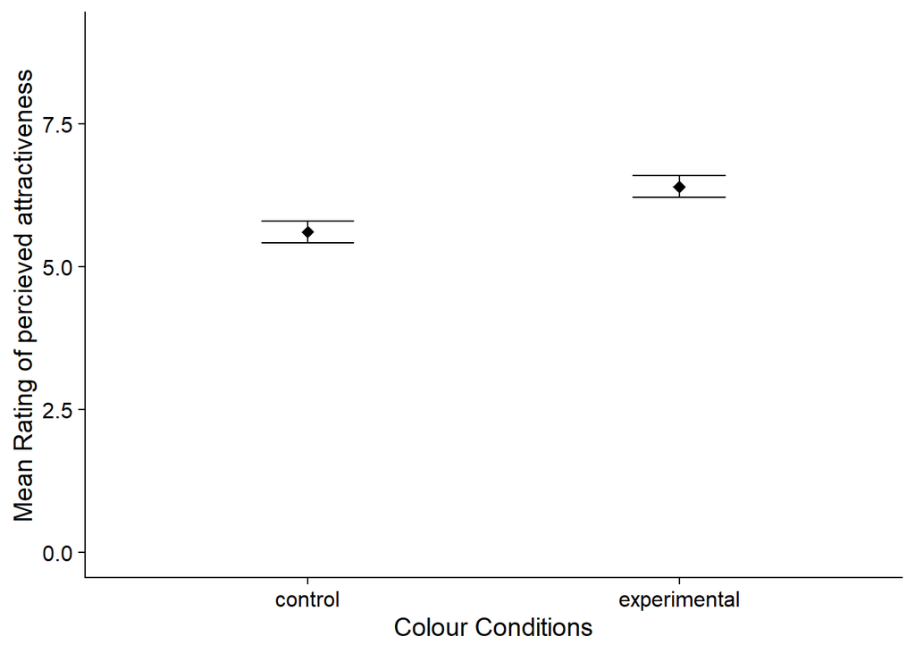

```r
Figure1
```

In this replication study of Elliot’s (Elliot et al., 2010) Experiment 1, we inestivated whether, as predicted, women would rate men’s perceived attractiveness differently depending on colour condition, white as control and red as experimental, using an independent-measures *t*-test. The t-test showed that the means in the two conditions differed (*M*<sub>diff</sub> = -0.79, 95% CI [-1.07, -0.51]) and there is a significant difference between the two colour groups on rating of perceived attractiveness (*t* (118) = -5.57, *p* = < .001).  
My plot in Figure1, shows women’s mean ratings of perceived attractiveness on a 9-point scale are higher for the experimental red colour condition with a mean of 6.396825. Whereas, their mean ratings of perceived attractiveness are lower in the control white colour condition with a mean of 5.608187. Therefore, having a difference of -0.788638 rating point in means, giving a large signal-to-noise ratio. We calculated our composite scores by finding the mean of each female participants perceived attractiveness scores for the three questions asked. The error bars result for each colour condition do not overlap, shows results can be significantly different. These results suggest women perceived men with a red coloured background as more attractive than men with a white background. This result is significant as our t-test found a p-value of less than .001, with a confidence interval of less than 0.1% chance of the results being incorrect.

# Discussion

The aim of this investigation was to conduct a replication study from Elliot’s (Elliot et al., 2010) experiment 1 to answer the research question, do Women find Men more attractive in conjunction with the colour red. I hypothesised that Women will perceive higher attractiveness of men with red background in the experimental condition, compared to women’s perceived attractiveness of men with white background in the control condition. The results from my independent measures t-test found the results from my study are significant as women rated male perceived attractiveness higher in the red colour condition. My plot shows an overall higher mean in perceived attractiveness scores in the experimental condition with the error bars not overlapping showing there is a significant difference between the means. My research findings support my hypothesis, answering the research question that women do in fact find men more attractive with the colour red. Therefore, I accept my alternative hypothesis and reject the null hypothesis. In Elliot et al.’s original study, he found that the female participants rated men as being more attractive in the red condition compared to the white. Elliot’s findings were significant and suggested that participants were unwarily influenced by the colour red, adding support to the red effect (Elliot et al., 2010). My findings from this replication study matches the same pattern of results as Elliot’s original experiment, as both found higher perceived attractiveness ratings on a 9-point-scale in the red colour condition. Both Elliot’s original experiment result and my replication study supports the red effect being investigated as red colour has been found to unconsciously influence Women’s viewing of attractiveness in men (Elliot et al., 2010).

In contrast, a later 3 studies by Peperkoorn et al. (Peperkoorn, Roberts and Pollet, 2016) testing Elliot’s research question, found contradictory results in the red effect. This study tested whether women’s clothing colour affected how males perceived their attractiveness and found no red effect as there was no difference in attractiveness ratings between colour conditions in all 3 studies (Peperkoorn, Roberts and Pollet, 2016). My research result doesn’t follow the pattern of result found by Peperkoorn. This creates uncertainty in whether there is a significant red effect. However, Peperkoorn’s research investigated Male perceptions on Women attractiveness, where Elliot’s was opposite, suggesting there may only be a red effect occurring in Women perceiving Men’s attractiveness (Elliot et al., 2010; Peperkoorn, Roberts and Pollet, 2016). Further research by Elliot found not only attractiveness influenced through the colour red but also sexual desirability and status, suggesting women perceive men in red as having higher status giving an innate advantageous response to perceiving these men as more attractive (Elliot et al., 2010; Hesslinger, Goldbach and Carbon, 2015).

Challenging results to Elliot’s findings also come from Hesslinger’s close replication study of Elliot’s experiment 1. Hesslinger found no significant red effect on perceived attractiveness, instead found other factors such as apparel style affecting status perception influenced attractiveness ratings. Formal apparel had a significant effect on attractiveness ratings as these men were perceived as higher status, again enhancing attractiveness (Hesslinger, Goldbach and Carbon, 2015). However, the colour red has been linked to perceptions of dominance and high status, therefore Hesslinger’s significant high status effect on attractiveness could have been influenced by red unknowingly (Little and Hill, 2007; Peperkoorn, Roberts and Pollet, 2016). My replication study results contrast Hesslinger’s replication study results of Elliot’s experiments 1, as I found a significant red effect in perceived attractiveness. This contrast in findings challenges the red effect, suggesting other factors such as status and apparel style have larger influence on male attractiveness (Hesslinger, Goldbach and Carbon, 2015). Research by Little et al. into red and its effect in signalling dominance suggests the red effect only occurs in women for mate preference with red being associated with dominance, higher status and higher testosterone levels, giving a biological basis for the red effect (Little and Hill, 2007).

Gregory Francis’s research analysis of Elliot’s original studies found Elliot’s studies were tainted by publication bias as the likelihood all 12 of Elliot’s findings would have rejected the null hypothesis is as small as .005 and very unlikely. Francis argues that Elliot’s research is unreliable and deemed as unscientific, as a result making the influence of the red effect unknown with too little research evidence to support it (Francis, 2013). On the other hand, Elliot explains publication bias was found only in one of the research areas and that their research as a whole shouldn’t be dismissed as being significant and S. C. Roberts et al.’s research findings were comparable with his own (Elliot and Maier, 2013).

Strengths of my replication study is high consistency between the two-colour group conditions as both the control and experimental conditions have a mean age around 20 years old using the same age group of from 18 to 25 years old. This makes the samples in each condition controlled and results more comparable and reliable, strengthening the significance of my findings. My study also uses the same standardised three questions from Elliot’s experiment with the same standardised 9-point rating scale being used to respond to each question in both conditions, again ensuring the highest control between the variables. The participants were unaware of the aim of the study in the involvement of colour adding support to my findings being accurate, reducing the chance of participant effects. Whereas, my replication study is limit by using a small sample size of 120 participants from the same age group and student population. Resulting in my findings being unrepresentative of other age groups or other culture populations, lacking ecological validity. Another limitation is a lack in temporal validity as social cognitive associations influenced with red and colours in general can change over time, as well as colours having different meaning in various cultures. Therefore, results may on be applied to specific populations for a certain amount of time. 30 participants had to be removed due to error, anomalies and ethical reasons. These questions the control in other participants as there may be more uncertainties in data collection that could affect the data. There are significant findings in research evidence in support of the red effect that cannot be overlooked, but the power in how effective its influence is for perceived attractiveness is challenged. The full extent to which the red effect is real is still uncertain. However, there is still a red effect influence found for women perceiving men’s attractiveness as other factors such as status, sexual desire and dominance are linked with the colour red support my Elliot and my own findings (Elliot et al., 2010). Suggesting there is somewhat of red effect influencing women’s perceptions, but not enough research to know the extent the red effect overall. More research investigations such as meta-analysis using larger, wider population samples across age groups and gender is needed to gain more insight cross-culturally in the influence of the red effect as this effect may be real in one population but may not be found in others (Peperkoorn, Roberts and Pollet, 2016).

Ultimately, through my own finding that women do perceive men as being more attractive in conjunction with the colour red, supporting Elliot’s original study, there is a real red effect in women perceiving men. Yet, the power of its influence and the extent that it occurs in the wider population, cross-culturally and across genders is challenged and still unknown, requiring further research.

# References

Elliot,

A. J., Niesta Kayser, D., Greitemeyer, T., Lichtenfeld, S., Gramzow, R. H., Maier, M. A., & Liu, H. (2010). Red, rank, and romance in women viewing men. *Journal of Experimental Psychology: General, 139*(3), 399.

Elliot, A. J. and Maier, M. A. (2013) ‘The red-attractiveness effect, applying the ioannidis and trikalinos(2007b) test, and the broader scientific context: A reply to francis (2013)’. *Journal of Experimental Psychology: General. American Psychological Association Inc., 142*(1), pp. 297–300

Francis, G. (2013) ‘Comment publication bias in Red, Rank, and Romance in women viewing men, by Elliot et al. (2010)’, *Journal of Experimental Psychology: General. American Psychological Association Inc., pp. 292–296*

Hesslinger, V. M., Goldbach, L. and Carbon, C. C. (2015) ‘Men in red: A reexamination of the red-attractiveness effect’, *Psychonomic Bulletin and Review. Springer New York LLC, 22*(4), pp. 1142–1148

Little, A. C. and Hill, R. A. (2007) ‘ATTRIBUTION TO RED SUGGESTS SPECIAL ROLE IN DOMINANCE SIGNALLING’, *Journal of Evolutionary Psychology, 5*(4), pp. 161–168

Peperkoorn, L. S., Roberts, S. C. and Pollet, T. V (2016) ‘Revisiting the Red Effect on Attractiveness and Sexual Receptivity: No Effect of the Color Red on Human Mate Preferences’.